# ETC5523: Communicating with Data

Tutorial 6

Emi Tanaka

Week 6

**Please do Preparation *before* the tutorial!**

## 🔧 Preparation

Install the `janitor` R package.

```r
install.packages(c("janitor", "ggridges", "ggforce"))
```

Note that most questions do not have a definitive “correct” answer so be creative!

## 💎️ Exercise 6A

**Diamonds**

The dataset `diamonds` in the `ggplot2` package includes attributes and price on 53,940 diamonds. Some of the attributes, such as carat, cut, color and clarity, are known to influence the price. Figures 1 and 2 explain the order of classifications for color and clarity of diamonds. Use this data to answer the following questions.

[output not shown]

[figure not shown]

Figure 1: Diamond color image sourced from https://beyond4cs.com

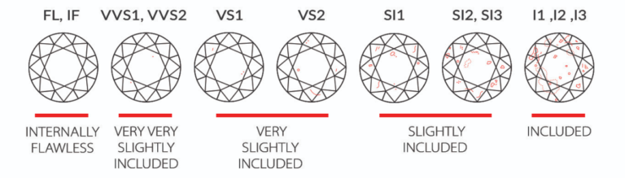

Figure 2: Diamond clarity image sourced from https://www.onlinediamondbuyingadvice.com

```r
data("diamonds", package = "ggplot2")
dplyr::glimpse(diamonds)
```

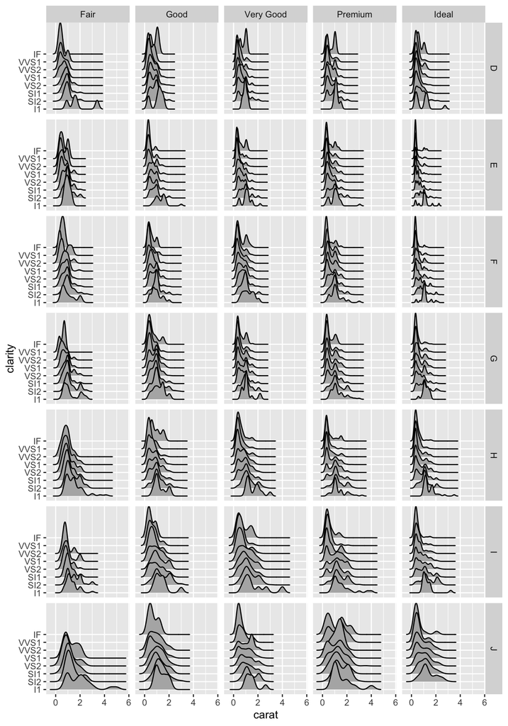

Figure 3: Density plots for carats by cut, clarity and color.

```r
ggplot(diamonds, aes(carat, clarity)) +
  ggridges::geom_density_ridges(scale = 4) +
  facet_grid(color ~ cut)
```

1. Is there anything unusual about the distribution of diamond weights (i.e. carats)? Which plot do you think shows it best? How might you explain the pattern you find?
2. What about the distribution of the prices? Can you find any unexpected feature? Which graphics best shows this unexpected feature?
3. Suppose that this data are a representative sample of diamonds around the world.
   1. The exploratory plot in Figure 3 shows that there are hardly any diamonds with high carats that have high level of clarity. Produce a plot to support/contradict this claim.
   2. A diamonds whole seller wants to convince the jewellery store owner that $5,000 for a 2 carat diamond is a bargain price. Show a graphic that supports this story.

## 🚢 Exercise 6B

**Titanic**

*Titanic* was a British ship that can carry over 2,000 people. It is most well known for meeting its end at the 15th April 1912 when it hit an iceberg and sank.

```r
dfB <- as.data.frame(Titanic)
glimpse(dfB)
```

```
## Rows: 32
## Columns: 5
## $ Class    <fct> 1st, 2nd, 3rd, Crew, 1st, 2nd, 3rd, Crew, 1st, 2nd, 3rd, Cre…
## $ Sex      <fct> Male, Male, Male, Male, Female, Female, Female, Female, Male…
## $ Age      <fct> Child, Child, Child, Child, Child, Child, Child, Child, Adul…
## $ Survived <fct> No, No, No, No, No, No, No, No, No, No, No, No, No, No, No, …
## $ Freq     <dbl> 0, 0, 35, 0, 0, 0, 17, 0, 118, 154, 387, 670, 4, 13, 89, 3, …
```

1. “Women and children first” was a code of conduct where the lives of women and children are to be saved first in life-threatening situations. Produce a graphic that best supports whether this code of conduct was applied when Titanic was sinking.
2. There are far more men than women on board Titanic. This is because majority of crew members are male. Produce a graphic to show this.

## 🔧 Exercise 6C

**Global Crop Yields**

The data below comes from [Our World in Data](https://ourworldindata.org/crop-yields) and sourced from [Tidy Tuesday](https://github.com/rfordatascience/tidytuesday/blob/master/data/2020/2020-09-01/readme.md). This data contains agricultural yields across crop types and by country from 1960 onwards.

```r
key_crop_yields <- readr::read_csv('https://raw.githubusercontent.com/rfordatascience/tidytuesday/master/data/2020/2020-09-01/key_crop_yields.csv') %>%
  janitor::clean_names()
dplyr::glimpse(key_crop_yields)
```

```
## Rows: 13,075
## Columns: 14
## $ entity                         <chr> "Afghanistan", "Afghanistan", "Afghani…
## $ code                           <chr> "AFG", "AFG", "AFG", "AFG", "AFG", "AF…
## $ year                           <dbl> 1961, 1962, 1963, 1964, 1965, 1966, 19…
## $ wheat_tonnes_per_hectare       <dbl> 1.0220, 0.9735, 0.8317, 0.9510, 0.9723…
## $ rice_tonnes_per_hectare        <dbl> 1.5190, 1.5190, 1.5190, 1.7273, 1.7273…
## $ maize_tonnes_per_hectare       <dbl> 1.4000, 1.4000, 1.4260, 1.4257, 1.4400…
## $ soybeans_tonnes_per_hectare    <dbl> NA, NA, NA, NA, NA, NA, NA, NA, NA, NA…
## $ potatoes_tonnes_per_hectare    <dbl> 8.6667, 7.6667, 8.1333, 8.6000, 8.8000…
## $ beans_tonnes_per_hectare       <dbl> NA, NA, NA, NA, NA, NA, NA, NA, NA, NA…
## $ peas_tonnes_per_hectare        <dbl> NA, NA, NA, NA, NA, NA, NA, NA, NA, NA…
## $ cassava_tonnes_per_hectare     <dbl> NA, NA, NA, NA, NA, NA, NA, NA, NA, NA…
## $ barley_tonnes_per_hectare      <dbl> 1.0800, 1.0800, 1.0800, 1.0857, 1.0857…
## $ cocoa_beans_tonnes_per_hectare <dbl> NA, NA, NA, NA, NA, NA, NA, NA, NA, NA…
## $ bananas_tonnes_per_hectare     <dbl> NA, NA, NA, NA, NA, NA, NA, NA, NA, NA…
```

The code below is one way to extract the map data and draws the map.

```r
library(ggplot2)
map_df <- map_data("world")
dplyr::glimpse(map_df)
```

```
## Rows: 99,338
## Columns: 6
## $ long      <dbl> -69.89912, -69.89571, -69.94219, -70.00415, -70.06612, -70.…
## $ lat       <dbl> 12.45200, 12.42300, 12.43853, 12.50049, 12.54697, 12.59707,…
## $ group     <dbl> 1, 1, 1, 1, 1, 1, 1, 1, 1, 1, 2, 2, 2, 2, 2, 2, 2, 2, 2, 2,…
## $ order     <int> 1, 2, 3, 4, 5, 6, 7, 8, 9, 10, 12, 13, 14, 15, 16, 17, 18, …
## $ region    <chr> "Aruba", "Aruba", "Aruba", "Aruba", "Aruba", "Aruba", "Arub…
## $ subregion <chr> NA, NA, NA, NA, NA, NA, NA, NA, NA, NA, NA, NA, NA, NA, NA,…
```

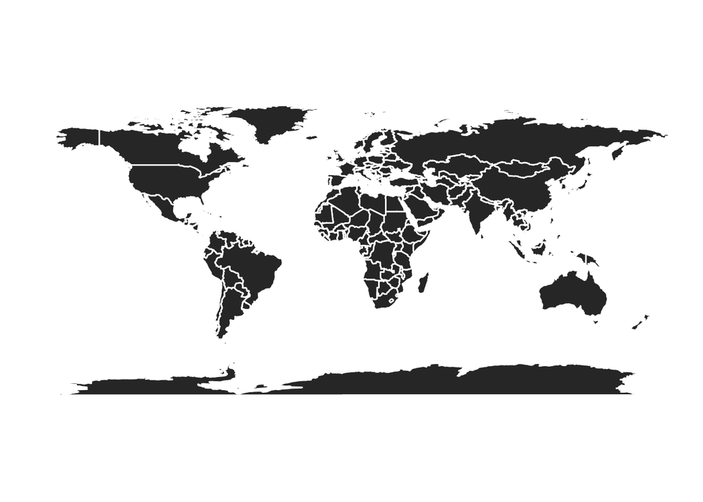

```r
ggplot(map_df, aes(long, lat, group = group)) +
  geom_polygon(color = "white") +
  coord_equal() +
  theme_void()
```

1. Produce a choropleth map of the wheat yield by country in 1998 and then in 2018.
2. Produce a single graphic that highlights one major change in wheat yield in 2018 compared to 1998.
3. You’re on the quest to find the 2018 World Crop Capital for each crop type! Produce graphic(s) to show which countries have the greatest crop yields per hectare. Publish this to your RPub account and submit your RPub url to Moodle.
4. Global crop production has been increasing over time. Produce a graphic that shows this effectively.